# The Spotif-Identifiers

## A tutorial by Seif Younis, Matthew Lee, and Jeffrey Jiang

# Overview

For many music fans, nothing beats the feeling of finding out that their favorite artist is releasing or has just recently released new music, especially if it's in the form of a new album. Thanks to audio streaming platforms, it's easier than ever to access such new music as it comes out, down to the minute it becomes available on streaming services. But what is the consensus on this new record 1 month, 2 months, 6 months after its release? Among fans and listeners, does the new album meet the standards set by the previous album as a worthwhile effort? Is it better? Worse? Why? And is there a way to predict it?

There are numerous music publications and fan forums that attempt to answer that question for a given artist and album. But for this tutorial, we're not seeking to predict critical appeal; that's a question for another day. Instead, we want to predict an outcome that can more feasibly be quantified, an outcome that we believe matters even more than acclaim: album popularity. In essence, we want to look at how much engagement an artist's latest album is getting compared to their previous one.

So how to measure popularity for a given album? We could go the route of looking up physical and digital sales. But likely the more worthwhile, and frankly more convenient, option is to look at how the record has performed on streaming services. In the present day, streaming has become the preferred option of listening to music for many, largely eclipsing more established mediums like radio and CD's. It is estimated that as of Q2 2021, there were [over 500 million paying subscribers](https://www.forbes.com/sites/eamonnforde/2022/01/19/spotify-comfortably-remains-the-biggest-streaming-service-despite-its-market-share-being-eaten-into/?sh=516d74fb3474) on music streaming services globally. As a result, we believe that streaming data is a worthwhile metric of an album's commercial success.

There are numerous music streaming services available, but we want to single out Spotify for our analysis for a number of reasons. For one, it's undoubtedly the biggest streaming service. Spotify controls [just over 30% of the global market share](https://www.midiaresearch.com/blog/music-subscriber-market-shares-q2-2021) for paid audio streaming subscriptions, compared to runner-up Apple Music at 15%. While it's true that a sizable portion of Spotify's usage can be attributed to its podcast selection, the fact remains that Spotify is a significant force in the music industry.

Additionally, we decided to use Spotify for our analysis due to the data we can acquire from the [Spotify Web API](https://developer.spotify.com/documentation/web-api/reference/#/). We delve more into the API and what we can learn from it later in the tutorial.

We recognize that some albums might just be one-offs, or that an artist might not be that invested in a particular album's success. But such music remains valuable data for our investigations, no matter the intent behind it.

```python
%%capture
%pip install spotipy;
# from google.colab import drive
# drive.mount('/content/drive')
import spotipy
from spotipy.oauth2 import SpotifyOAuth

import requests
import numpy as np
import pandas as pd

from matplotlib import pyplot as plt
import matplotlib.image as mpimg

from sklearn import tree
from sklearn.model_selection import train_test_split
from sklearn import metrics
import sklearn.model_selection as ms
import graphviz
import pydotplus
```

# Establishing Connection with Spotify API

To get started using the Spotify API, each of us created clients with our developer accounts. This was necessary in order to be able to send requests to the API and receive data from responses. The Python library [Spotipy](https://spotipy.readthedocs.io/en/2.19.0/) provides a useful abstraction for sending API requests.

```python
# Seif
SEIF_CLIENT_ID = '9f04d70e757945dfbbc56cee93a3a939'
SEIF_CLIENT_SECRET = 'de1649089eb648c9a198185fbd049286'
SEIF_REDIRECT_URI = 'https://google.com'
s_sp = spotipy.Spotify(auth_manager=SpotifyOAuth(
    client_id=SEIF_CLIENT_ID, client_secret=SEIF_CLIENT_SECRET,
    redirect_uri=SEIF_REDIRECT_URI, open_browser=False))

# Matt
MATT = '3idcqu4aeydqy5du38veifczk'
MATT_CLIENT_ID='3bef335281474758b9a2e5446402bdb1'
MATT_CLIENT_SECRET='feb981cda783489a9d1498b1d76bd96d'
MATT_REDIRECT_URI='https://google.com'
m_sp = spotipy.Spotify(auth_manager=SpotifyOAuth(
    client_id=MATT_CLIENT_ID, client_secret=MATT_CLIENT_SECRET,
    redirect_uri=MATT_REDIRECT_URI, open_browser=False))

# Jeff
JEFF_CLIENT_ID = '8a359c645d1348e58dcc23dc9d59e034'
JEFF_CLIENT_SECRET = 'bf4ce78ee6894601bf36b4a0c45f2074'
JEFF_REDIRECT_URI = 'https://google.com'
j_sp = spotipy.Spotify(auth_manager=SpotifyOAuth(
    client_id=JEFF_CLIENT_ID, client_secret=JEFF_CLIENT_SECRET,
    redirect_uri=JEFF_REDIRECT_URI, open_browser=False))
```

# Gathering Artists

We created our own list of artists to investigate for this tutorial. We took this approach for several reasons.

1. We wanted to limit the artists we considered to ones that have been releasing music in the past 7-8 years or so, since that's around the time that streaming services became the near ubiquitous means of music consumption that it is today. As a result, streaming popularity would be a more meaningful metric of commercial success for such albums.
2. We specifically wanted to look at artists that have released two or more albums so we could investigate streaming engagement across multiple long-form musical releases.
3. These artists are some of our favorites, so we had that much more of a vested interest in investigating the outcomes of how these artists' albums were received.

So we each made playlists featuring the artists we wanted to include. Initially, each of us had separate lists of artists. Later in the tutorial, we combine these lists to form a master list with 135 artists.

```python
# Collect URIs of the artists associated with all songs in playlist

# SEIF
seif_playlist_id = '7wdAwqqqsJwbCFk1ythqX7'
seif_playlist = s_sp.playlist_items(seif_playlist_id)
seif_artists = []
for i, item in enumerate(seif_playlist['items']):
      seif_artists.append(item['track']['artists'][0]['uri'])

# MATT
matt_playlist_id = '7HyZrEv8AV2thQdei6nFbG'
matt_playlist = m_sp.playlist_items(matt_playlist_id)
matt_artists = []
for i, item in enumerate(matt_playlist['items']):
      matt_artists.append(item['track']['artists'][0]['uri'])

# JEFF
jeff_playlist_id = '5pecpdLoXi7zIPNbizTBcy'
jeff_playlist = j_sp.playlist_items(jeff_playlist_id)
jeff_artists = []
for i, item in enumerate(jeff_playlist['items']):
      jeff_artists.append(item['track']['artists'][0]['uri'])
```

# Getting Artists' Latest Two Core Albums

For each artist we use, we try to make sure we are only getting core albums in their discography, since some albums listed on Spotify may not fit this definition. In order to achieve this we implement the following checks.

1. We assume any album with parentheses in its title is a deluxe, remix, remaster, or otherwise updated version of a core album. Much of the time, these updated albums will be listed separately from their standard counterparts, and their resulting popularity may be different from the standard edition. Therefore, if an album's title contains parenthesis, it is not a core album and should not be counted.
2. We also assume every album is named differently. If an album contains the name of an earlier album, it is not a new album and shouldn't be added.

As far as we know, there is no definitive way to extract core albums, but these checks help reduce our chance of error.

```python
# Get artists' latest two core albums
def get_latest_albums(artist):
  artist_albums = s_sp.artist_albums(artist, 'album', 'US')['items']

  latest_albums = []
  for album in artist_albums:
    album_info = {
        "name": album['name'],
        "release_date": album['release_date'],
        "total_tracks": album['total_tracks'],
        "uri": album['uri'],
    }

    # Check album names don't contain parentheses and that both albums
    # included are named differently
    if not "(" in album['name']:
      if len(latest_albums) == 0:
        latest_albums.append(album_info)
      else:
          if album['name'] in latest_albums[0]['name']:
            latest_albums[0] = album
          else:
            if album['name'] != latest_albums[0]['name']:
              latest_albums.append(album_info)
              break

  return latest_albums
```

# Album Popularity and Audio Features

Spotify has a popularity score for each album we can use in our analysis. From the API documentation on the popularity score for an individual song:

*The popularity of a track is a value between 0 and 100, with 100 being the most popular. The popularity is calculated by algorithm and is based, in the most part, on the total number of plays the track has had and how recent those plays are. Generally speaking, songs that are being played a lot now will have a higher popularity than songs that were played a lot in the past.*

An album's popularity score is derived mathematically from track popularity. One might understandably think that earlier albums are always "more popular" because they've had more time to accrue streams. But newer albums can overtake a previous album in popularity with fewer streams if those streams are recent and plentiful enough to indicate that an artist is getting a significant amount of engagement with their new material.

By looking at each artist's two latest albums, we aim to explain why the most recent album might be more (or less) popular than its predecessor. To do this, we take a deep dive into the audio features that characterize each album. These characteristics are taken from Spotify's own measures of audio features and include danceability, energy, loudness, speechiness, acousticness, instrumentalness, liveness, valence, tempo, and duration.

1. Danceability is a value between 0.0 and 1.0 that measures how suitable a track is for dancing. It takes into account the tempo, rhythm stability, beat strength, and overall regularity of a song.
2. Energy is a value between 0.0 and 1.0 that refers to how intense a track feels to a listener. Energetic songs often feel fast, loud, and noisy. Energy is affected by the dynamic range, perceived loudness, timbre, onset rate, and general entropy of a track.
3. Loudness is measured in decibels (dB), and is taken to be an average of the volumn across an entire track.
4. Speechiness measures the presence of spoken words in a track. Higher values indicate a track that is akin to media like a talk show or an audio book, whereas lower values indicate a track that contains few speech signatures.
5. Acousticness is a value between 0.0 and 1.0 that describes the acoustic quality of a track.
6. Instrumentalness detects whether a track contains no vocals. Higher values indicate less vocal content, and thus genres like rap generally have lower values.
7. Liveness measures the likeliness that a track was performed live. It works by detecting the presence of an audience in the recording.
8. Valence is a value between 0.0 and 1.0 that depicts how positive a track is. Higher values indicate a track that is more happy and cheerful, while lower values indicate a track that is more sad and depressed.
9. Tempo is a measure of the overall speed of a track. It is in units of beats per minute (BPM) and is taken to be the average beat duration of a track.
10. Duration records the length of a track, and is measured in milliseconds.

Note that Spotify provides its own measures of audio features for individual tracks. Thus, to aggregate the audio features for entire albums, we take the median of the audio features across all of the tracks. This gives us a new set of values that we can use to characterize the album and that are more resilient to outliers.

# Creating a Dataframe Containing Artists' Two Latest Albums

Below is another helper function we created to add info for each artist's two latest albums to the master dataframe. It will contain two rows for each artist. For each artist's albums, we will get their song data, including the properties we explained above. Then we get the median value of each property value for a given album and add all of this information to the dataframe.

```python
# Add artists' latest two albums to master dataframe
def add_artist_to_df(artist, latest_albums):
  artist_df = pd.DataFrame()

  # Iterate over two latest albums
  for album in latest_albums:
    artist_data = s_sp.artist(artist)
    album_data = s_sp.album(album['uri'])

    # Get album info
    album['artist_followers'] = int(artist_data['followers']['total'])
    album['popularity'] = album_data['popularity']
    album = {key: [value] for key, value in album.items()}
    album_df = pd.DataFrame.from_records(album).drop(columns=['name', 'uri'])

    album_tracks = album_data['tracks']['items']
    track_uris = [track['uri'] for track in album_tracks]

    # Get audio features for each track of an album
    track_data = s_sp.audio_features(tracks=track_uris)
    track_data = pd.DataFrame.from_records(track_data).drop(
        columns=['type', 'id', 'uri', 'track_href', 'analysis_url',
                 'key', 'mode', 'time_signature'])

    # Get the average of all track properties.
    for col in track_data.columns:
      # Convert milliseconds to minutes
      if col == 'duration_ms':
        track_data.loc[0, col] = track_data[col].median() / (1000*60)
      else:
        track_data.loc[0, col] = track_data[col].median()

    # Only need one row of track data
    track_data.drop(range(1, len(track_data)), inplace=True)

    result = pd.merge(album_df, track_data, how='cross')
    result.insert(0, 'artist', artist_data['name'])

    artist_df = pd.concat([artist_df, result])

  return artist_df
```

Below, we create the master dataframe and call the two helper functions for each artist. We make sure an artist has at least two albums before adding their album info to the dataframe. The resulting dataframe is output below.

```python
# In total, we acquired 135 unique artists with at least 2 albums each.
all_albums = pd.DataFrame()
all_artists = seif_artists + matt_artists + jeff_artists
no_dups = []
[no_dups.append(x) for x in all_artists if x not in no_dups]
all_artists = no_dups

# Add each artist to master dataframe
for artist in all_artists:
  latest_albums = get_latest_albums(artist)
  if len(latest_albums) == 2:
    latest_albums = add_artist_to_df(artist, latest_albums)
    all_albums = pd.concat([all_albums, latest_albums])

# Clean up dataframe
all_albums = all_albums.sort_values(by=['artist', 'release_date'], ascending=True)
all_albums.rename(columns = {'duration_ms':'duration_mins'}, inplace=True),
all_albums = all_albums.dropna(axis='columns')
all_albums = all_albums.reset_index().drop('index', axis=1)
all_albums
```

|  | artist | artist_followers | popularity | release_date | total_tracks | danceability | energy | loudness | speechiness | acousticness | instrumentalness | liveness | valence | tempo | duration_mins |
| --- | --- | --- | --- | --- | --- | --- | --- | --- | --- | --- | --- | --- | --- | --- | --- |
| 0 | 5 Seconds of Summer | 8515507 | 50 | 2018-12-21 | 20 | 0.4595 | 0.9040 | -4.6560 | 0.07190 | 0.00473 | 0.000000 | 0.6495 | 0.3830 | 120.9920 | 4.030342 |
| 1 | 5 Seconds of Summer | 8515507 | 39 | 2020-03-27 | 13 | 0.5710 | 0.7220 | -3.6080 | 0.04520 | 0.17300 | 0.000000 | 0.1210 | 0.4610 | 134.9480 | 3.400483 |
| 2 | Against All Logic | 112857 | 49 | 2018-02-17 | 11 | 0.7620 | 0.8360 | -5.9280 | 0.04990 | 0.15300 | 0.772000 | 0.1110 | 0.2790 | 116.0030 | 5.680050 |
| 3 | Against All Logic | 112857 | 36 | 2020-02-07 | 9 | 0.6840 | 0.7660 | -6.6710 | 0.05080 | 0.36900 | 0.632000 | 0.2330 | 0.2770 | 120.0100 | 5.198333 |
| 4 | Alec Benjamin | 3482171 | 78 | 2018-11-16 | 12 | 0.6660 | 0.5775 | -5.7555 | 0.03980 | 0.67650 | 0.000003 | 0.1935 | 0.5415 | 127.4345 | 3.077033 |
| ... | ... | ... | ... | ... | ... | ... | ... | ... | ... | ... | ... | ... | ... | ... | ... |
| 265 | ZHU | 770100 | 53 | 2018-09-07 | 14 | 0.7705 | 0.5840 | -7.6375 | 0.07145 | 0.09465 | 0.086700 | 0.1085 | 0.2800 | 119.0090 | 4.162992 |
| 266 | boy pablo | 984696 | 66 | 2018-10-05 | 7 | 0.5460 | 0.5370 | -10.7380 | 0.03250 | 0.02200 | 0.000115 | 0.1030 | 0.4840 | 117.9070 | 2.783333 |
| 267 | boy pablo | 984696 | 62 | 2020-10-23 | 13 | 0.6520 | 0.5690 | -10.2170 | 0.03390 | 0.23200 | 0.060500 | 0.1350 | 0.7150 | 106.9920 | 3.333333 |
| 268 | iKON | 3283896 | 19 | 2019-03-20 | 19 | 0.5580 | 0.8300 | -7.3080 | 0.07030 | 0.10300 | 0.000000 | 0.8150 | 0.4720 | 127.9500 | 3.763783 |
| 269 | iKON | 3283896 | 28 | 2019-12-04 | 27 | 0.5090 | 0.7760 | -6.7440 | 0.05460 | 0.14900 | 0.000000 | 0.6730 | 0.4270 | 129.9780 | 3.484667 |

270 rows × 15 columns

# Assessing Success of Artists

If an album is higher ranked in popularity compared to the album that came before, we designate the artist as having "succeeded", whereas an artist "fails" if the opposite is true. We recognize this doesn't necessarily mean the newer album is a "failure," as it can still do impressive numbers. But even small popularity differences can mean significant streaming disparities, and we assume every artist wants to maintain or exceed their current engagement levels with each new release. In an age where the musical sphere is more saturated than ever, this can be a crucial indicator of an artist's longevity.

Below, we calculate the difference in value of overall song properties between an artist's album and add those differences to the dataframe, along with a column indicating an artist's success.

```python
# # Calculate difference in song properties between albums and add to dataframe
i=5
for i in range(5, 15):
  col = all_albums.columns[i]

  all_albums[col + '_diff'] = \
    all_albums.groupby('artist')[col].diff()

# Get differences between release dates in unit of months
all_albums.loc[:, ('release_date')] = pd.to_datetime(all_albums['release_date'],
                                              infer_datetime_format=True)
all_albums['release_date_diff'] =  \
  all_albums.groupby('artist')['release_date'].diff()/np.timedelta64(1, 'M')

success_df = all_albums.groupby('artist')['popularity'].apply(list)
success = []

# Assign success to each artist
for artist, popularity in success_df.items():
  if len(popularity) != 1:
    if popularity[1] >= popularity[0]:
      success.append('Yes')
    else:
      success.append('No')

# Add success values to dataframe
i=1
for s in success:
  all_albums.at[i, 'success'] = s
  i+=2

all_albums
```

|  | artist | artist_followers | popularity | release_date | total_tracks | danceability | energy | loudness | speechiness | acousticness | ... | loudness_diff | speechiness_diff | acousticness_diff | instrumentalness_diff | liveness_diff | valence_diff | tempo_diff | duration_mins_diff | release_date_diff | success |
| --- | --- | --- | --- | --- | --- | --- | --- | --- | --- | --- | --- | --- | --- | --- | --- | --- | --- | --- | --- | --- | --- |
| 0 | 5 Seconds of Summer | 8515507 | 50 | 2018-12-21 | 20 | 0.4595 | 0.9040 | -4.6560 | 0.07190 | 0.00473 | ... | NaN | NaN | NaN | NaN | NaN | NaN | NaN | NaN | NaN | NaN |
| 1 | 5 Seconds of Summer | 8515507 | 39 | 2020-03-27 | 13 | 0.5710 | 0.7220 | -3.6080 | 0.04520 | 0.17300 | ... | 1.048 | -0.0267 | 0.16827 | 0.000000 | -0.5285 | 0.078 | 13.956 | -0.629858 | 15.178956 | No |
| 2 | Against All Logic | 112857 | 49 | 2018-02-17 | 11 | 0.7620 | 0.8360 | -5.9280 | 0.04990 | 0.15300 | ... | NaN | NaN | NaN | NaN | NaN | NaN | NaN | NaN | NaN | NaN |
| 3 | Against All Logic | 112857 | 36 | 2020-02-07 | 9 | 0.6840 | 0.7660 | -6.6710 | 0.05080 | 0.36900 | ... | -0.743 | 0.0009 | 0.21600 | -0.140000 | 0.1220 | -0.002 | 4.007 | -0.481717 | 23.655517 | No |
| 4 | Alec Benjamin | 3482171 | 78 | 2018-11-16 | 12 | 0.6660 | 0.5775 | -5.7555 | 0.03980 | 0.67650 | ... | NaN | NaN | NaN | NaN | NaN | NaN | NaN | NaN | NaN | NaN |
| ... | ... | ... | ... | ... | ... | ... | ... | ... | ... | ... | ... | ... | ... | ... | ... | ... | ... | ... | ... | ... | ... |
| 265 | ZHU | 770100 | 53 | 2018-09-07 | 14 | 0.7705 | 0.5840 | -7.6375 | 0.07145 | 0.09465 | ... | -0.261 | 0.0235 | 0.03710 | 0.002650 | -0.0410 | 0.002 | 0.015 | -0.101783 | 25.298261 | No |
| 266 | boy pablo | 984696 | 66 | 2018-10-05 | 7 | 0.5460 | 0.5370 | -10.7380 | 0.03250 | 0.02200 | ... | NaN | NaN | NaN | NaN | NaN | NaN | NaN | NaN | NaN | NaN |
| 267 | boy pablo | 984696 | 62 | 2020-10-23 | 13 | 0.6520 | 0.5690 | -10.2170 | 0.03390 | 0.23200 | ... | 0.521 | 0.0014 | 0.21000 | 0.060385 | 0.0320 | 0.231 | -10.915 | 0.550000 | 24.608308 | No |
| 268 | iKON | 3283896 | 19 | 2019-03-20 | 19 | 0.5580 | 0.8300 | -7.3080 | 0.07030 | 0.10300 | ... | NaN | NaN | NaN | NaN | NaN | NaN | NaN | NaN | NaN | NaN |
| 269 | iKON | 3283896 | 28 | 2019-12-04 | 27 | 0.5090 | 0.7760 | -6.7440 | 0.05460 | 0.14900 | ... | 0.564 | -0.0157 | 0.04600 | 0.000000 | -0.1420 | -0.045 | 2.028 | -0.279117 | 8.509415 | Yes |

270 rows × 27 columns

# Ouput Artist Success

Below we have aggregated every artist in our dataframe and broken down how many had "more successful" albums and how many didn't.

```python
successful_artists = all_albums.groupby('success')['artist'].apply(list)['Yes']
unsuccessful_artists = all_albums.groupby('success')['artist'].apply(list)['No']

print(len(successful_artists), "artists' latest album popularity exceeds that \
of their last")

print(len(unsuccessful_artists), "artists' latest album popularity failed to \
exceed that of their last")
```

```
56 artists' latest album popularity exceeds that of their last
79 artists' latest album popularity failed to exceed that of their last
```

# Reducing the Master Dataframe

We pared down the master dataframe a bit in order to make data visualization and analysis more convenient.

```python
album_changes = all_albums.dropna(axis='rows')
album_changes = album_changes.reset_index().drop(album_changes.columns[range(0, 15)], axis=1)
album_changes = album_changes.drop('index', axis=1)
album_changes
```

|  | danceability_diff | energy_diff | loudness_diff | speechiness_diff | acousticness_diff | instrumentalness_diff | liveness_diff | valence_diff | tempo_diff | duration_mins_diff | release_date_diff | success |
| --- | --- | --- | --- | --- | --- | --- | --- | --- | --- | --- | --- | --- |
| 0 | 0.1115 | -0.1820 | 1.0480 | -0.02670 | 0.16827 | 0.000000 | -0.5285 | 0.0780 | 13.9560 | -0.629858 | 15.178956 | No |
| 1 | -0.0780 | -0.0700 | -0.7430 | 0.00090 | 0.21600 | -0.140000 | 0.1220 | -0.0020 | 4.0070 | -0.481717 | 23.655517 | No |
| 2 | 0.0360 | -0.0160 | -0.4650 | 0.00725 | -0.01850 | -0.000002 | -0.0490 | 0.1235 | -15.9150 | -0.320250 | 18.398735 | No |
| 3 | 0.1425 | -0.1015 | -2.1955 | -0.01395 | -0.01130 | -0.012265 | -0.0860 | 0.2390 | 11.2375 | -0.071275 | 30.817881 | No |
| 4 | -0.0700 | -0.1540 | -1.1290 | -0.01070 | -0.14500 | 0.000000 | -0.0020 | -0.2980 | -0.0420 | -0.227133 | 19.778640 | Yes |
| ... | ... | ... | ... | ... | ... | ... | ... | ... | ... | ... | ... | ... |
| 130 | 0.0840 | 0.0720 | 0.1685 | -0.00275 | -0.13570 | 0.000000 | 0.0195 | 0.1640 | 15.0600 | 0.059733 | 28.518039 | No |
| 131 | 0.0740 | -0.1400 | 0.3810 | -0.08500 | 0.11200 | 0.219000 | 0.0200 | -0.0130 | 5.0150 | -0.772200 | 25.528245 | Yes |
| 132 | 0.0365 | -0.0950 | -0.2610 | 0.02350 | 0.03710 | 0.002650 | -0.0410 | 0.0020 | 0.0150 | -0.101783 | 25.298261 | No |
| 133 | 0.1060 | 0.0320 | 0.5210 | 0.00140 | 0.21000 | 0.060385 | 0.0320 | 0.2310 | -10.9150 | 0.550000 | 24.608308 | No |
| 134 | -0.0490 | -0.0540 | 0.5640 | -0.01570 | 0.04600 | 0.000000 | -0.1420 | -0.0450 | 2.0280 | -0.279117 | 8.509415 | Yes |

135 rows × 12 columns

# Visualizing Effects of Song Property Changes on Album Success

In order to better understand the effects of audio features on album success, we plotted the change in each audio feature against the success of an artist. Here, the success of an artist is defined by an increase in popularity between its first and second albums. On the x-axis, a success is indicated by the value 'Yes', and a failure is indicated by the value 'No'. The values along the y-axis represent the change in an audio feature between the two albums. Thus, we have 10 plots to analyze the effect of each audio feature on album success.

By plotting changes in audio features against album success, our goal is to see if we can identify any patterns in the distributions of the data points. For instance, we might take a look at the danceability plot, and if we observe that the distribution of points in the case of album success ('Yes') is denser for positive values of danceability difference relative to to that in the case of album failure ('No'), then we might positively correlate album success with danceability.

For this, we chose to visualize our data using violin plots. This allows us to see the shapes of the distributions for album successes and failures before comparing them. In this way, we can reliably check each audio feature for possible indicators of album success.

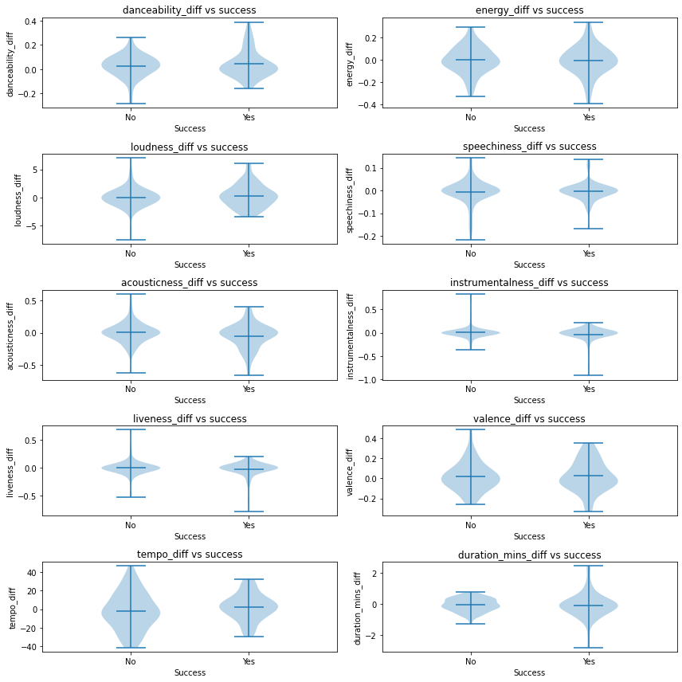

```python
# Helper function for formatting plots
def set_axis_style(ax, labels):
    ax.xaxis.set_tick_params(direction='out')
    ax.xaxis.set_ticks_position('bottom')
    ax.set_xticks(np.arange(1, len(labels) + 1))
    ax.set_xticklabels(labels=labels)
    ax.set_xlim(0.25, len(labels) + 0.75)
    # ax.set_xlabel('Sample name')

# Plot
fig, axes = plt.subplots(5, 2, figsize=(12, 12))

# Violin plots
success_values = ['No', 'Yes']
for i in range(0, 10):
  row = i // 2
  col = i % 2
  dance_success = []
  for value in success_values:
    lst = album_changes.loc[album_changes['success'] == value]
    lst = list(lst[album_changes.columns[i]])
    dance_success.append(lst)

  song_prop = str(album_changes.columns[i])

  axes[row, col].violinplot(dance_success, showmeans=True)
  axes[row, col].set_xlabel('Success')
  axes[row, col].set_ylabel(song_prop)
  axes[row, col].set_title(song_prop + ' vs success')
  set_axis_style(axes[row, col], success_values)

fig.tight_layout()
```

We can see that none of these feature variables by themselves demonstrate a significant relationship between changes to the song properties and whether a newer album is more successful than the previous. But perhaps the interaction between these variables can be accounted for in a model we use to predict album success, which may mean that observing changes in all these properties can act as a more robust predictor.

# Predicting Album Streaming Success

From the dataset, we split it into training and testing. To train our decision tree we used sklearn's function. With the trained model, we feed our testing data and found that we got an accuracy close to 60%.

```
Fitting 10 folds for each of 400 candidates, totalling 4000 fits
y_pred:  [0 0 0 0 0 0 0 0 0 0 0 0 0 0 0 0 0 0 0 0 0 0 0 0 0 0 0 0 0 0 0 0 0 0 0 0 0
 0 0 0 0]
Accuracy: 0.5853658536585366
```

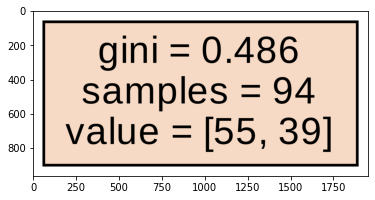

```python
# Initialize decision tree
dt = tree.DecisionTreeClassifier()

# Variables
features = album_changes.columns[0:11] # Insert features such as danceability

# Change 'Yes' and 'No' categories to binary values
if album_changes['success'].dtype == 'O':
  album_changes['success'] = album_changes['success'].map({'Yes': 1, 'No': 0})

X = album_changes[features]
y = album_changes['success']

# Split dataset to 70% train and 30% test
X_train, X_test, y_train, y_test = train_test_split(X, y, test_size=0.3,
                                                    random_state=1)
# Hyperparameter tuning
param_grid = {
    'max_depth': [2, 3, 5, 10, 20],
    'min_samples_leaf': [5, 10, 20, 50, 100],
    "criterion":['gini','entropy'],
    "min_samples_split":range(2,10),
}
grid = ms.GridSearchCV(dt, param_grid=param_grid, cv=10, verbose=1, n_jobs=-1)
grid.fit(X_train, y_train)

# Use best DT model found via Grid Search Validation
dt = grid.best_estimator_

# Predict success values using DT
y_pred = dt.predict(X_test)
print('y_pred: ', y_pred)
print("Accuracy:", metrics.accuracy_score(y_test, y_pred))

dt_viz = tree.export_graphviz(dt, out_file=None,
                                feature_names=features,
                                filled=True)

pydot_graph = pydotplus.graph_from_dot_data(dt_viz)
pydot_graph.set_size('"100,10!"')
pydot_graph.write_png('decisionTree.png')
img = mpimg.imread('decisionTree.png')
imgplot = plt.imshow(img)
plt.show()

# Predict future success
# dt.predict([[]]) # Insert value to predict.
```

# Conclusion

Using the Spotify API, we were able to retrieve information on artists from users' playlists. This gave us data to work with. From an artist's album, Spotify provides us with extra data regarding an album. Spotify provides features such as danceability, loudness, energy, and etc. From this API function, we define a new column in the dataframe where we consider successful artists as someone who has gained 'popularity' from their previous album to their latest. Our goal was to see if we could find a relationship between this extra data and an album's popularity. To do this, we made violin plots of audio features against album success. However, we were not able to identify any noticeable patterns in the plots, and thus we could not conclude from this alone that there was any meaningful association between audio features and album success. But this does give us at least some insight into what doesn't affect album success.

```python
# %%shell
# jupyter nbconvert --to html Album_Success.ipynb
```